# Calum INLA example

Jakob J. Assmann

2024-03-12

```r
knitr::opts_chunk$set(echo = TRUE)
# Dependencies
library(tidyverse)
library(sp)
library(gstat)
library(spdep)
library(spatialreg)
library(ggplot2)
library(cowplot)
library(colorspace)
library(pbapply)
library(broom)
library(kableExtra)
library(INLA)

# Opttional set to short inal summary
#inla.setOption(short.summary = TRUE)
```

## Load data

Note, I made a small change to keep the X and Y coordinates (remove = F).

```r
# Load data
kl_data <- read_csv("s2-kl-smooth-joined.csv", show_col_types = FALSE) %>%
  st_as_sf(coords = c('X', 'Y'), remove = F, crs = 32608) %>%
  group_by(id) %>%
  filter(row_number() == 7) %>%
  ungroup()
```

## Prepare “node” vector for INLA matern2d model

INLA nodes are arranged as sequential numbers where numbers ascend column-wise from the top-left corner of the grid towards the bottom-right. See Fig 7.1 in this document: https://becarioprecario.bitbucket.io/inla-gitbook/ch-spatial.html

In our case, we can derive the column and row numbers from the UTM coordinates as follows:

col_number = (x - min(x)) / 10  
row_number = (max(y) - y) / 10

We can then assign a regularly increasing index (1:n), by infilling the cells no accounted for.

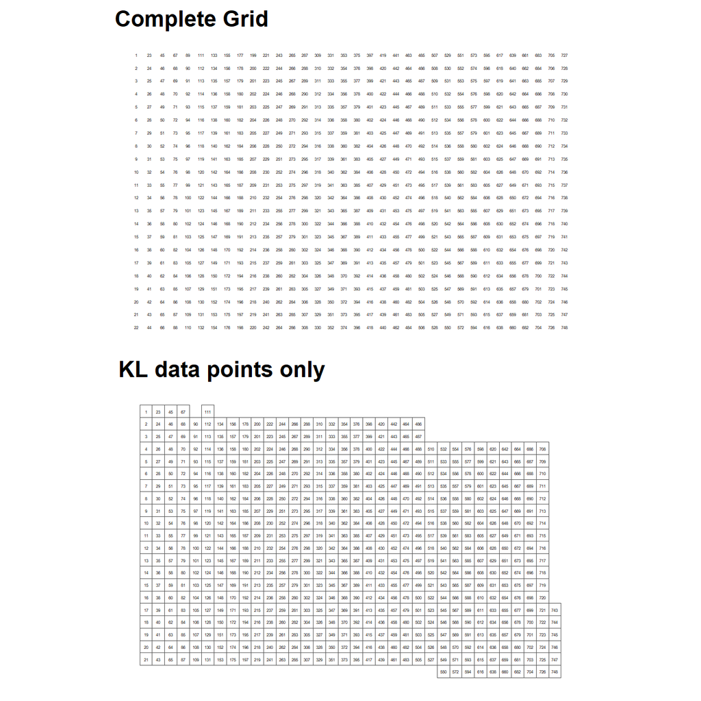

```r
# Calculate row and col_numbers
kl_data <- kl_data %>%
  # Calculate min X and max >
  mutate(min_x = min(.$X),
         max_y = max(.$Y)) %>%
  # Calczulate colum and row numbers for each cell (top-left to bottom-right corner)
  # We shift by one a R is 1- based
  mutate(col_number = 1 + ((X - min_x) / 10),
         row_number = 1 + ((max_y - Y) / 10)) %>%
  # Arrange dataset accordingly
  arrange(col_number, row_number)

# Derrive spatial index in INLA fashion (running number)
# Optain number of cols and rows
n_col = max(kl_data$col_number)
n_row = max(kl_data$row_number)
# Expand grid and add index
complete_grid <- expand.grid(1:n_col, 1:n_row) %>%
  # Rename columns
  select(col_number = Var1, row_number = Var2) %>%
  # Rearrange same as data frame above (top-left to bottom-right)
  arrange(col_number, row_number) %>%
  # Generate index ("node")
  mutate(node = 1:nrow(.))

# Add node to kl_data, skipping those with no data (left_join)
kl_data <- kl_data %>%
  left_join(complete_grid, by = c("col_number", "row_number"))

# Plot to visualise
complete_grid_plot <- ggplot() +
  geom_text(data = complete_grid,
            mapping = aes(x = col_number, y = row_number, label = node),
            size = 1) +
  labs(title = "Complete Grid") +
  scale_y_reverse() +
  coord_equal() +
  theme_map()
kl_node_plot <- ggplot() +
  geom_sf(data = st_buffer(st_geometry(kl_data), 5, endCapStyle = "SQUARE"),
          fill = NA) +
  geom_sf_text(data = kl_data,
               aes(label = node),
               size = 1) +
  labs(title = "KL data points only") +
  theme_map()

plot_grid(complete_grid_plot,
          kl_node_plot,
          nrow = 2)
```

Now we have a vector (“node”) that represents the spatial arrangement of the pixels in a way that INLA can understand.

## Fitting a simple INLA model

Next, we fit a super simple INLA model, not worrying about priors for now.

```r
# Specify formula
formula_matern <- ndvi.max ~ snow.auc +
                  f(node,
                    model = "matern2d",
                    nrow = n_row,
                    ncol = n_col)
# Fit model
model_matern <- inla(formula = formula_matern,
                     data = kl_data,
                     family = "gaussian",
                     control.predictor = list(compute = TRUE),
                     control.compute = list(dic = TRUE,
                                            waic = TRUE,
                                            cpo = TRUE,
                                            return.marginals.predictor = TRUE),
                     keep = TRUE)
# Print summary
summary(model_matern)
```

```
##
## Call:
##    c("inla.core(formula = formula, family = family, contrasts = contrasts,
##    ", " data = data, quantiles = quantiles, E = E, offset = offset, ", "
##    scale = scale, weights = weights, Ntrials = Ntrials, strata = strata,
##    ", " lp.scale = lp.scale, link.covariates = link.covariates, verbose =
##    verbose, ", " lincomb = lincomb, selection = selection, control.compute
##    = control.compute, ", " control.predictor = control.predictor,
##    control.family = control.family, ", " control.inla = control.inla,
##    control.fixed = control.fixed, ", " control.mode = control.mode,
##    control.expert = control.expert, ", " control.hazard = control.hazard,
##    control.lincomb = control.lincomb, ", " control.update =
##    control.update, control.lp.scale = control.lp.scale, ", "
##    control.pardiso = control.pardiso, only.hyperparam = only.hyperparam,
##    ", " inla.call = inla.call, inla.arg = inla.arg, num.threads =
##    num.threads, ", " blas.num.threads = blas.num.threads, keep = keep,
##    working.directory = working.directory, ", " silent = silent, inla.mode
##    = inla.mode, safe = FALSE, debug = debug, ", " .parent.frame =
##    .parent.frame)")
## Time used:
##     Pre = 0.962, Running = 1.9, Post = 0.193, Total = 3.05
## Fixed effects:
##               mean    sd 0.025quant 0.5quant 0.975quant   mode kld
## (Intercept)  0.527 0.004      0.519    0.527      0.535  0.527   0
## snow.auc    -0.003 0.001     -0.004   -0.003     -0.001 -0.003   0
##
## Random effects:
##   Name     Model
##     node Matern2D model
##
## Model hyperparameters:
##                                              mean       sd 0.025quant  0.5quant
## Precision for the Gaussian observations 204061.27 48580.09  126940.28 197785.61
## Precision for node                         103.40    56.43      22.44     93.08
## Range for node                              25.80     8.98      14.76     23.81
##                                         0.975quant      mode
## Precision for the Gaussian observations  317138.72 185268.31
## Precision for node                          237.03     65.36
## Range for node                               49.24     19.59
##
## Deviance Information Criterion (DIC) ...............: -5586.67
## Deviance Information Criterion (DIC, saturated) ....: 1253.69
## Effective number of parameters .....................: 612.19
##
## Watanabe-Akaike information criterion (WAIC) ...: -5762.23
## Effective number of parameters .................: 318.48
##
## Marginal log-Likelihood:  1872.00
## CPO, PIT is computed
## Posterior summaries for the linear predictor and the fitted values are computed
## (Posterior marginals needs also 'control.compute=list(return.marginals.predictor=TRUE)')
```

The fit returns a more conservative estimate of the slope than the other models we have fitted so far, but the result are still “significant”. In Bayesian, we’d say “the credible interval does not overlap with zero”, or, given the data and model the 95% interval of the posterior distribution indicates a negative slope with a mean of -0.003.

Also the range parameter “Range for node” has a mean posterior estimate of 25. As INLA works in arbitrary distances (i.e., number of neighbours), this seems like rather a lot (250 m?). That said, the results seem to make a lot of sense, see below.

Let’s retrieve the fitted values and marginal predictions.

```r
# Calculate marginal predictions depending on snow.auc only
kl_data$preds <- model_matern$summary.fixed[1,1] +
                 kl_data$snow.auc * model_matern$summary.fixed[2,1]
# Add model fitted values and residuals to data frame
kl_data$fitted <- model_matern$summary.linear.predictor$mean
kl_data$residuals <- kl_data$ndvi.max - model_matern$summary.linear.predictor$mean
```

Graph fitted values and marginal predictions.

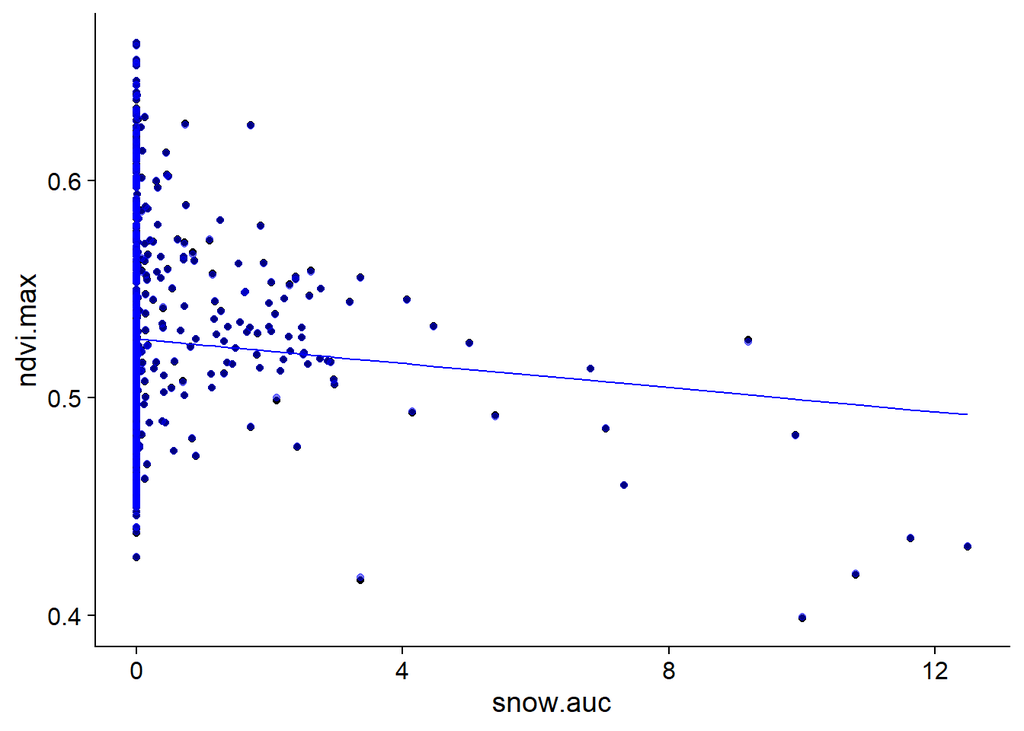

```r
# Graph data, fitted values and predictions
ggplot(data = kl_data) +
  geom_point(aes(x = snow.auc, y= ndvi.max)) +
  geom_point(aes(x = snow.auc, y = fitted),
             colour = "blue",
             alpha = 0.5) +
  geom_line(aes(x = snow.auc, preds),
            colour = "blue") +
  theme_cowplot()
```

The fitted values (blue) are very close to the observed values. Suggesting that the model (including the spatial random effect) does manage to account for a lot of the variation in the data (very good!). The fitted slope and intercept seem both reasonable given the observed data.

Let’s have a look at how the predictions are distributed in space:

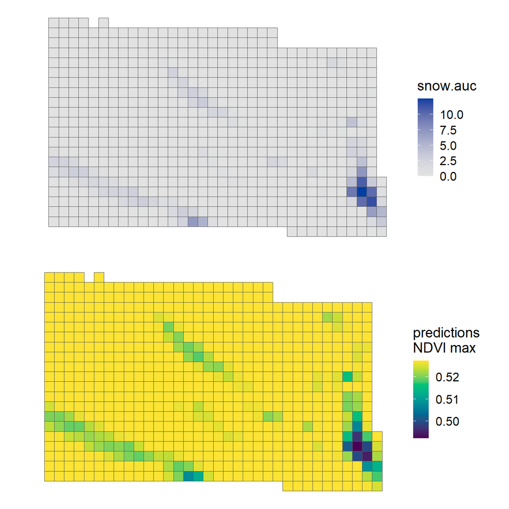

```r
plot_grid(ggplot() +
  geom_sf(data = st_buffer(kl_data, 5, endCapStyle = "SQUARE"),
          aes(fill = snow.auc)) +
  scale_fill_continuous_sequential("blue") +
  labs(fill = "snow.auc") +
  theme_map(),
  ggplot() +
  geom_sf(data = st_buffer(kl_data, 5, endCapStyle = "SQUARE"),
          aes(fill = preds)) +
  scale_fill_continuous_sequential("viridis", rev = F) +
  labs(fill = "predictions\nNDVI max") +
  theme_map(),
  nrow = 2)
```

This looks great and seems to make sense given the hypothesised relationship.

Next we need to check whether there is still any autocorrelation in the residuals and whether these follow a Gaussian distribution (as assumed).

## Graph residuals

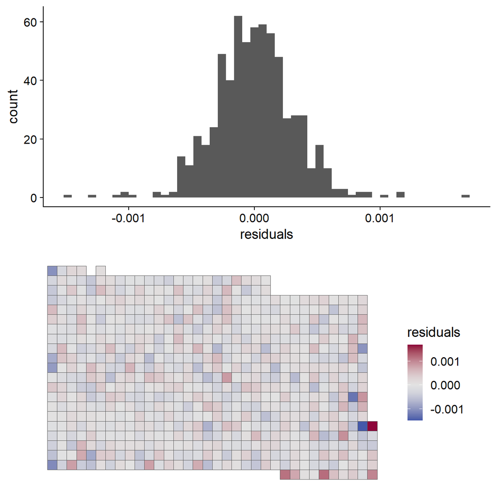

```r
# Graph residuals as histogram and in space
plot_grid(ggplot(kl_data) +
  geom_histogram(aes(x = residuals), bins = 50) +
  labs(x = "residuals") +
  theme_cowplot(),
ggplot() +
  geom_sf(data = st_buffer(kl_data, 5, endCapStyle = "SQUARE"), aes(fill = residuals)) +
  scale_fill_continuous_diverging() +
  theme_map(),
nrow = 2)
```

The histogram of the residuals follows a nice normal distribution - great!

It also seems like the model does an excellent job at accounting for the spatial autocorrelation. The residual are are seemingly randomly distributed in space.

As a last check, let’s look at the variation accounted for by the latent spatial effect.

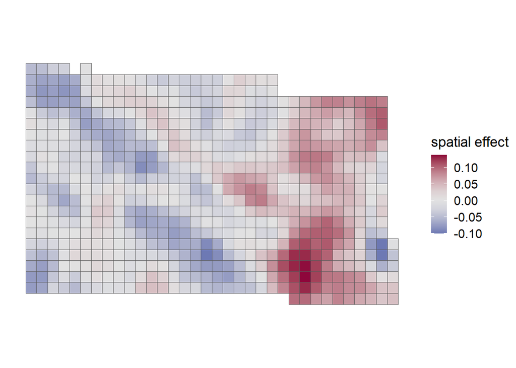

```r
ggplot() +
  geom_sf(data = st_buffer(kl_data, 5, endCapStyle = "SQUARE"),
          aes(fill = ndvi.max - preds - residuals)) +
  scale_fill_continuous_diverging() +
  labs(fill = "spatial effect") +
  theme_map()
```

The latent spatial effect of the model manages to account for a lot of the residual variation. That makes a lot of ecological sense, as we’d think that the majority in NDVI variation is not explained by our predictor.

The way I understand the spatial latent effect is that INLA fits an an “random error term” to each individual node where the error term is described by a matern function based on the surrounding neighbourhood of the node. I am not 100% certain that is really how it works, but will run this past a colleague to dig deeper.

End of file.